# # Regression Analysis of Household Trip Rates

## Description

We develop multiple regression models to estimate household trip rates.

- We focus on four different types of home-based trips, including home-based work (HBW), home-based shopping (HBS), home-based recreation (HBR), and home-based other (HBO).
- The dependent variable is the number of linked trips, not place-based trips, at the houehold level. For example, in the Year 2011 Oregon Travel and Activity Survey, which is a place-based survey, a transit trip is coded with 3 trips, including transit access, in transit, and transit egress. In our study, we use linked trips; that is, we convert the transit trip from 3 trips to 1 trip.
- We have two sets of independent variables: sociodemographic characteristics of households (SD) and built environment characteristics of household’s home census block groups (BE).
  - the SD variables: household size, number of workers, number of students, household income, etc.
  - the BE variables: EPA’s Smart Location Database (Density (D1), Diversity (D2), Design (D3), Transit (D4), and Destination Accessibility (D5)

### Load data from the PostgreSQL database

- the activity file of the 2011 OTAS
- the household file of the 2011 OTAS
  - households’ home census block groups (hcbg) were spatialled joined
- EPA’s Smart Location Database
  - downloaded from [Smart Location Mapping](http://www.epa.gov/smartgrowth/smartlocationdatabase.htm) for our study area, followed by converting the Coordinate Reference System to EPSG 2913
  - for a full description of all variablels, please refer to [its Users’ Guide](http://www.epa.gov/smartgrowth/pdf/sld_userguide.pdf)
- we combined the household file and the Smart Location Database, which is hh_sld

### Create a dependent variable for each home-based trip purpose : number of linked trips per household

- hba (home-based all); all home-based trips
- hbw (home-based work); work, not including all other activities at work and work related activities
- hbs (home-based shopping); both routine and special shopping
- hbr (home-based recreation); both outdoor and indoor recreation
- hbo (home-based other); other home-based trips

```r
# create a new data set without the Change-of-Mode activities in the middle of the day to use only linked trips
linked <- subset(act, !(tpurp==7 & actNo!=1 & actNo!=maxAct))
# update actNo and maxAct
linked$actNo <- with(linked, ave(plano, sampn,perno, FUN=seq))
linked$maxAct <- with(linked, ave(actNo, sampn,perno, FUN=length))
# update lastaggact
linked$lastaggact <- c(NA, linked$thisaggact[-length(linked$thisaggact)])
linked$lastaggact[linked$actNo==1] <- NA
# update last_tpurp
linked$last_tpurp <- c(NA, linked$tpurp[-length(linked$tpurp)])
linked$last_tpurp[linked$actNo==1] <- NA
# identity trip purposes
linked$h2o <- with(linked, ifelse(actNo!=1
                                  & (lastaggact=='Home'|lastaggact=='WorkAtHome')
                                  & (thisaggact!='Home'&thisaggact!='WorkAtHome'), 1, 0))
linked$o2h <- with(linked, ifelse(actNo!=1
                                  & (lastaggact!='Home'&lastaggact!='WorkAtHome')
                                  & (thisaggact=='Home'|thisaggact=='WorkAtHome'), 1, 0))
linked$hba <- with(linked, ifelse(h2o==1|o2h==1, 1, 0))
linked$hbw <- with(linked, ifelse((h2o==1&tpurp==3)|(o2h==1&last_tpurp==3), 1, 0))
linked$hbs <- with(linked, ifelse((h2o==1&(tpurp==13|tpurp==14))|(o2h==1&(last_tpurp==13|last_tpurp==14)), 1, 0))
linked$hbr <- with(linked, ifelse((h2o==1&(tpurp==20|tpurp==21))|(o2h==1&(last_tpurp==20|last_tpurp==21)), 1, 0))
linked$hbo <- with(linked, ifelse((h2o==1&(tpurp!=3&tpurp!=13&tpurp!=14&tpurp!=20&tpurp!=21))
                                  |(o2h==1&(last_tpurp!=3&last_tpurp!=13&last_tpurp!=14&last_tpurp!=20&last_tpurp!=21)), 1, 0))
# calculate the number of linked trips by home-based trip purposes at the household level
hba <- setNames(aggregate(linked[,"hba"], by=list(linked$sampn), "sum"), c("sampn", "numtrips"))
hbw <- setNames(aggregate(linked[,"hbw"], by=list(linked$sampn), "sum"), c("sampn", "numtrips"))
hbs <- setNames(aggregate(linked[,"hbs"], by=list(linked$sampn), "sum"), c("sampn", "numtrips"))
hbr <- setNames(aggregate(linked[,"hbr"], by=list(linked$sampn), "sum"), c("sampn", "numtrips"))
hbo <- setNames(aggregate(linked[,"hbo"], by=list(linked$sampn), "sum"), c("sampn", "numtrips"))
```

### Add independent variables

- the sociodemographic characteristics of households
- the built environment characteristics of household home census block groups

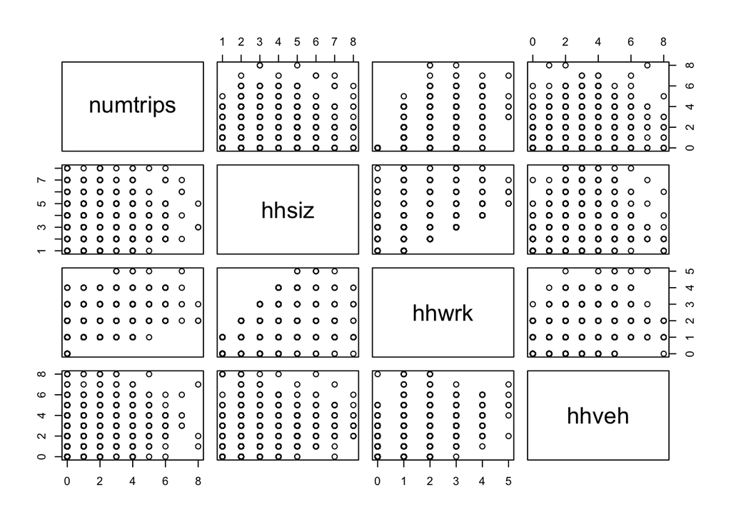

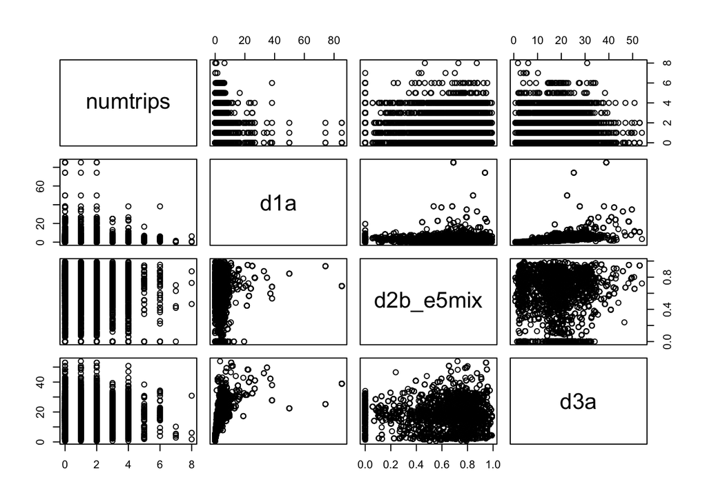

### Develop regression models to estimate household trip rates

```
##
## Calls:
## HBA: lm(formula = f1, data = hba)
## HBW: lm(formula = f1, data = hbw)
## HBW_workers: lm(formula = f1, data = hbw[which(hbw$hhwrk != 0), ])
## HBS: lm(formula = f1, data = hbs)
## HBR: lm(formula = f1, data = hbr)
## HBO: lm(formula = f1, data = hbo)
##
## =======================================================================================
##                     HBA         HBW     HBW_workers     HBS         HBR         HBO
## ---------------------------------------------------------------------------------------
## (Intercept)       1.009*      0.244       0.318       0.247       0.317       0.201
##                  (0.468)     (0.158)     (0.177)     (0.182)     (0.191)     (0.395)
## hhsiz             1.930***    0.029       0.039       0.333***    0.248***    1.320***
##                  (0.074)     (0.025)     (0.029)     (0.029)     (0.030)     (0.063)
## hhwrk             0.571***    0.847***    0.758***   -0.129***   -0.019      -0.128*
##                  (0.063)     (0.021)     (0.034)     (0.024)     (0.026)     (0.053)
## hhstu             1.324***   -0.060*     -0.074*     -0.210***    0.102**     1.492***
##                  (0.079)     (0.026)     (0.031)     (0.030)     (0.032)     (0.066)
## hhveh             0.028       0.043**     0.044*     -0.063***   -0.027       0.075
##                  (0.048)     (0.016)     (0.019)     (0.019)     (0.019)     (0.040)
## hhlic            -0.064       0.001       0.041       0.096*      0.052      -0.213**
##                  (0.097)     (0.033)     (0.040)     (0.037)     (0.039)     (0.081)
## flexc            -0.501*     -0.131      -0.136      -0.001      -0.185*     -0.184
##                  (0.231)     (0.078)     (0.087)     (0.090)     (0.094)     (0.195)
## ---------------------------------------------------------------------------------------
## R-squared            0.571       0.300       0.165       0.043       0.084       0.518
## adj. R-squared       0.571       0.299       0.164       0.042       0.083       0.518
## sigma                3.329       1.123       1.223       1.292       1.360       2.808
## F                 1430.187     460.244     179.021      48.436      98.465    1155.434
## p                    0.000       0.000       0.000       0.000       0.000       0.000
## Log-likelihood  -16902.625   -9897.631   -8793.537  -10798.967  -11129.530  -15805.734
## Deviance         71377.648    8129.965    8108.670   10751.918   11912.641   50795.657
## AIC              33821.250   19811.261   17603.074   21613.934   22275.059   31627.469
## BIC              33875.424   19865.435   17655.871   21668.108   22329.233   31681.642
## N                 6449        6449        5430        6449        6449        6449
## =======================================================================================
```

```
##
## Calls:
## HBA: lm(formula = f2, data = hba)
## HBW: lm(formula = f2, data = hbw)
## HBW_workers: lm(formula = f2, data = hbw[which(hbw$hhwrk != 0), ])
## HBS: lm(formula = f2, data = hbs)
## HBR: lm(formula = f2, data = hbr)
## HBO: lm(formula = f2, data = hbo)
##
## =======================================================================================
##                     HBA         HBW     HBW_workers     HBS         HBR         HBO
## ---------------------------------------------------------------------------------------
## (Intercept)      -0.399       0.103       0.151      -0.098      -0.051      -0.354
##                  (0.509)     (0.172)     (0.195)     (0.198)     (0.208)     (0.431)
## hhsiz             1.961***    0.024       0.034       0.340***    0.258***    1.338***
##                  (0.074)     (0.025)     (0.030)     (0.029)     (0.030)     (0.063)
## hhwrk             0.527***    0.839***    0.749***   -0.138***   -0.027      -0.147**
##                  (0.063)     (0.021)     (0.034)     (0.025)     (0.026)     (0.053)
## hhstu             1.315***   -0.058*     -0.070*     -0.212***    0.098**     1.486***
##                  (0.078)     (0.026)     (0.031)     (0.030)     (0.032)     (0.066)
## hhveh             0.127*      0.057***    0.061**    -0.039*     -0.004       0.113**
##                  (0.049)     (0.017)     (0.019)     (0.019)     (0.020)     (0.042)
## hhlic            -0.055       0.008       0.049       0.099**     0.052      -0.213**
##                  (0.096)     (0.033)     (0.040)     (0.038)     (0.039)     (0.082)
## flexc            -0.327      -0.114      -0.114       0.055      -0.140      -0.128
##                  (0.233)     (0.079)     (0.088)     (0.091)     (0.096)     (0.197)
## d1a               0.005      -0.037***   -0.047***    0.009       0.017       0.017
##                  (0.029)     (0.010)     (0.012)     (0.011)     (0.012)     (0.025)
## d1b              -0.012       0.028***    0.035***   -0.008      -0.012      -0.020
##                  (0.024)     (0.008)     (0.010)     (0.009)     (0.010)     (0.020)
## d1c5_ret10        0.011       0.034*      0.043*      0.016      -0.024      -0.015
##                  (0.042)     (0.014)     (0.017)     (0.016)     (0.017)     (0.036)
## d2a_jphh          0.039       0.002       0.002       0.009       0.011       0.017
##                  (0.025)     (0.008)     (0.010)     (0.010)     (0.010)     (0.021)
## d2b_e5mix         0.096      -0.030      -0.033       0.049       0.093      -0.016
##                  (0.177)     (0.060)     (0.070)     (0.069)     (0.072)     (0.150)
## d2a_ephhm         0.096       0.022       0.021       0.032      -0.005       0.048
##                  (0.278)     (0.094)     (0.111)     (0.108)     (0.114)     (0.235)
## d3a               0.043***   -0.002      -0.002       0.006       0.011*      0.028**
##                  (0.012)     (0.004)     (0.005)     (0.005)     (0.005)     (0.010)
## d3b               0.000       0.000       0.000       0.001       0.000      -0.001
##                  (0.001)     (0.000)     (0.001)     (0.001)     (0.001)     (0.001)
## ---------------------------------------------------------------------------------------
## R-squared            0.576       0.303       0.169       0.047       0.088       0.520
## adj. R-squared       0.575       0.301       0.167       0.045       0.086       0.519
## sigma                3.313       1.122       1.221       1.290       1.358       2.806
## F                  623.994     199.353      78.849      22.823      44.359     497.419
## p                    0.000       0.000       0.000       0.000       0.000       0.000
## Log-likelihood  -16856.995   -9880.323   -8777.907  -10779.387  -11109.952  -15786.904
## Deviance         70559.605    8096.812    8068.762   10702.379   11858.520   50622.145
## AIC              33745.990   19792.646   17587.815   21590.773   22251.905   31605.807
## BIC              33854.327   19900.983   17693.404   21699.110   22360.242   31714.144
## N                 6445        6445        5428        6445        6445        6445
## =======================================================================================
```

### Develop zero-inflated negative binomial (zinb) models

```r
zinb.hbw <- zeroinfl(numtrips ~ hhsiz + hhstu + hhveh + hhlic + flexc +
                 d1a + d1b + d1c5_ret10 + d2a_jphh + d2b_e5mix + d2a_ephhm + d3a + d3b | hhwrk,
                 data=hbw, dist="negbin", EM=TRUE)
summary(zinb.hbw)
```

```
##
## Call:
## zeroinfl(formula = numtrips ~ hhsiz + hhstu + hhveh + hhlic + flexc +
##     d1a + d1b + d1c5_ret10 + d2a_jphh + d2b_e5mix + d2a_ephhm +
##     d3a + d3b | hhwrk, data = hbw, dist = "negbin", EM = TRUE)
##
## Pearson residuals:
##       Min        1Q    Median        3Q       Max
## -2.49e+00 -8.28e-01 -3.33e-05  5.13e-01  4.49e+00
##
## Count model coefficients (negbin with log link):
##              Estimate Std. Error z value Pr(>|z|)
## (Intercept)  0.042267   0.132623    0.32  0.74995
## hhsiz        0.055932   0.019450    2.88  0.00403 **
## hhstu       -0.062867   0.019974   -3.15  0.00165 **
## hhveh        0.044272   0.012745    3.47  0.00051 ***
## hhlic        0.192958   0.023582    8.18  2.8e-16 ***
## flexc       -0.095079   0.059940   -1.59  0.11268
## d1a         -0.030561   0.009368   -3.26  0.00110 **
## d1b          0.022843   0.007220    3.16  0.00156 **
## d1c5_ret10   0.027694   0.011213    2.47  0.01352 *
## d2a_jphh     0.000333   0.007511    0.04  0.96459
## d2b_e5mix   -0.021458   0.048222   -0.44  0.65633
## d2a_ephhm    0.034561   0.078394    0.44  0.65931
## d3a         -0.001517   0.003448   -0.44  0.65996
## d3b          0.000253   0.000397    0.64  0.52435
## Log(theta)   9.863724   8.102195    1.22  0.22345
##
## Zero-inflation model coefficients (binomial with logit link):
##             Estimate Std. Error z value Pr(>|z|)
## (Intercept)     20.0      865.1    0.02     0.98
## hhwrk          -21.1      865.1   -0.02     0.98
## ---
## Signif. codes:  0 '***' 0.001 '**' 0.01 '*' 0.05 '.' 0.1 ' ' 1
##
## Theta = 19220.338
## Number of iterations in BFGS optimization: 1
## Log-likelihood: -8.29e+03 on 17 Df
```